Eubalaena

BOLDGenotyper v1.0.0

# Eubalaena

BOLDGenotyper Analysis Report

Generated: 2025-11-20 07:35:45

61

Total Samples

1

Genotypes

100.0%

Assignment Rate

## Analysis Summary

Total Samples

61

Samples analyzed

With Sequence Data

61

100.0% of total

Consensus Groups

1

Unique genotypes identified

Distinct species

Successfully Assigned

61

100.0% assignment rate

Mean Identity

99.5%

For assigned samples

Geographic coverage

## Pipeline Parameters

The following parameters were used for this analysis:

| Parameter | Value | Description |
| --- | --- | --- |
| **Clustering Threshold** | `0.03` (97.0% identity) | Maximum genetic distance for grouping sequences into consensus genotypes. Lower values create more groups with tighter genetic similarity. |
| **Similarity Threshold** | `0.5` (50% identity) | Minimum sequence identity required for assigning samples to genotypes. Samples below this threshold are marked as unassigned. |
| **Tie Margin** | `0.003` (0.3% difference) | Maximum identity difference between top matches to flag as ambiguous. Samples with (best - runner-up) < tie margin are flagged for manual review. |
| **Tie Threshold** | `0.95` (95% identity) | Minimum best-match identity required to consider tie detection. Prevents flagging low-quality matches as ties. |
| **Threads** | `4` | Number of parallel processing threads used. |
| **Phylogenetic Tree** | `False` | Whether phylogenetic tree was constructed. |

## Visualizations

📁 High-resolution images (PNG/PDF) and data files (JSON/CSV) available at: `visualization/`

### Relative Abundance by Ocean Basin

Relative abundance of genotypes across ocean basins

📁 Files: `visualization/Eubalaena_distribution_bar.png`, `Eubalaena_distribution_bar.pdf`, `Eubalaena_distribution_bar_data.json`

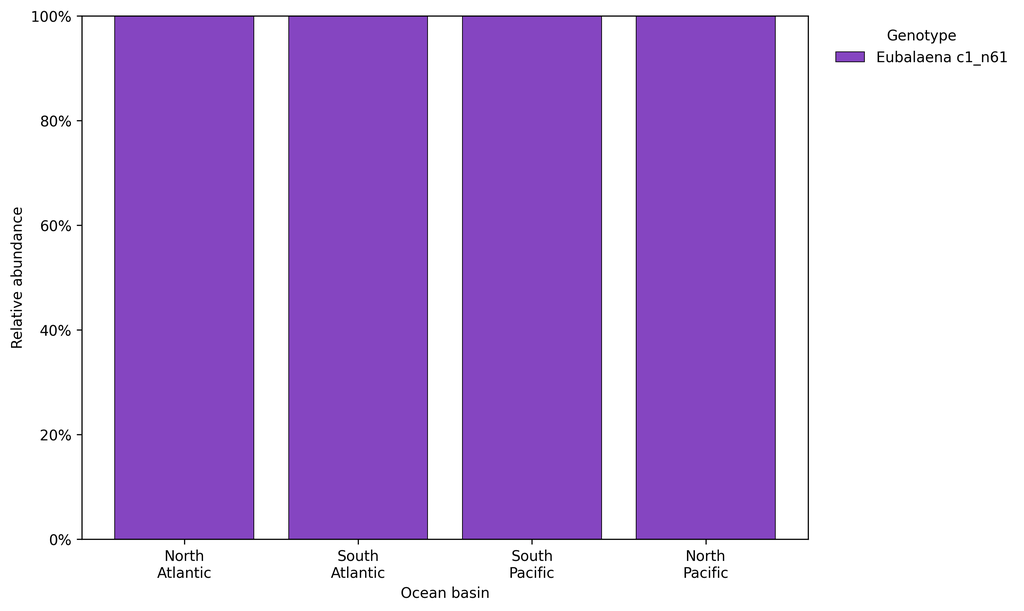

### Total Abundance by Ocean Basin

Total sample counts of genotypes across ocean basins

📁 Files: `visualization/Eubalaena_totaldistribution_bar.png`, `Eubalaena_totaldistribution_bar.pdf`, `Eubalaena_totaldistribution_bar_data.json`

[figure not shown]

### Total Abundance by Ocean Basin (Faceted)

Total sample counts faceted by species or genotype

📁 Files: `visualization/Eubalaena_distribution_bar_faceted.png`, `Eubalaena_distribution_bar_faceted.pdf`, `Eubalaena_distribution_bar_faceted_data.json`

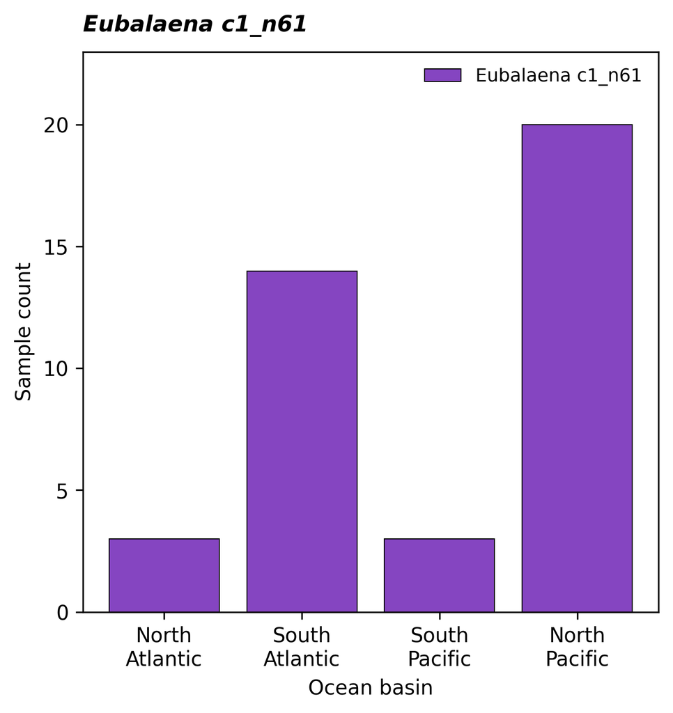

### Distribution Map

Geographic distribution of samples

📁 Files: `visualization/Eubalaena_distribution_map.png`, `Eubalaena_distribution_map.pdf`, `Eubalaena_distribution_map_data.json`

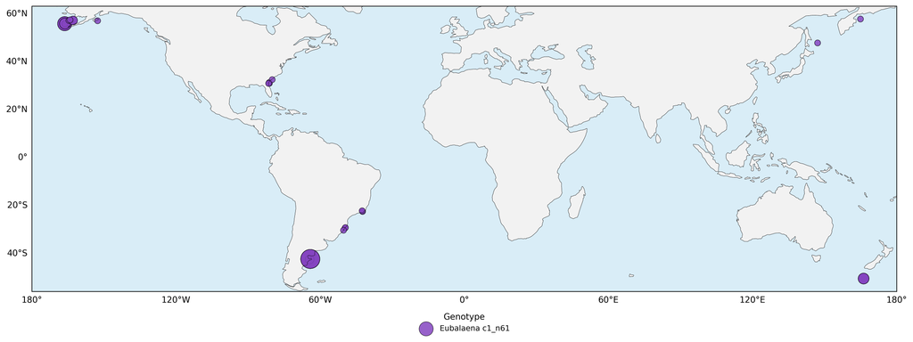

### Distribution Map (Faceted)

Geographic distribution faceted by species or genotype

📁 Files: `visualization/Eubalaena_distribution_map_faceted.png`, `Eubalaena_distribution_map_faceted.pdf`

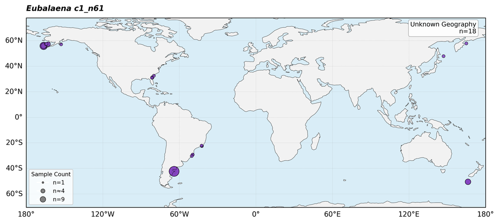

## Methods

Comprehensive analysis methodology and parameters suitable for reporting in peer-reviewed publications.

### 1. Analysis Overview

| **Pipeline Version** | BOLDGenotyper v1.0.0 |
| --- | --- |
| **Analysis Date** | 2025-11-20 |
| **Input File** | `data/Eubalaena.tsv` |

### 2. Sample Processing & Quality Control

| **Total samples loaded** | 83 |
| --- | --- |
| **Duplicate samples removed** | 20 |
| **Unique samples after deduplication** | 63 |
| **Coordinate quality filtering** | 61/63 (96.8%) retained |
| **Centroid coordinates excluded** | 2 |
| **Valid sequences for analysis** | 61 |

### 3. Sequence Dereplication

| **Algorithm** | Hierarchical clustering (average linkage) |
| --- | --- |
| **Alignment** | MAFFT `--auto` |
| **Trimming** | trimAl |
| **Minimum sequence length** | 400 bp |
| **Clustering threshold** | 0.03 (97.0% identity) |
| **Pairwise comparisons** | 1,830 |
| **Consensus genotypes identified** | 1 |

### 4. Genotype Assignment

| **Assignment method** | Edit distance (edlib) |
| --- | --- |
| **Similarity threshold** | 0.5 (50% identity) |
| **Tie detection margin** | 0.003 (0.3%) |
| **Tie detection threshold** | 0.95 (95% identity) |
| **Successfully assigned** | 61/61 (100.0%) |
| **Ambiguous assignments (ties)** | 0 |
| **Low confidence assignments** | 0 |

Phylogenetic tree construction was not enabled for this analysis.

### 6. Geographic Analysis

| **Reference dataset** | GOaS v1 (Global Oceans and Seas) |
| --- | --- |
| **Samples with coordinates** | 43/61 (70.5%) |
| **Ocean basin assignments** | 40/43 (93.0%) |
| **Outside known basins** | 3 |
| **Unknown location** | 21 samples |

### 7. Software & Dependencies

| **BOLDGenotyper** | v1.0.0 |
| --- | --- |
| **MAFFT** | Multiple sequence alignment (Katoh & Standley, 2013) |
| **trimAl** | Alignment trimming (Capella-Gutiérrez et al., 2009) |
| **edlib** | Edit distance calculation (Šošić & Šikić, 2017) |
| **GOaS** | Global Oceans and Seas dataset (Flanders Marine Institute, 2021) |

### 8. Methods Statement

DNA barcode sequences for Eubalaena were downloaded from the Barcode of Life Data System (BOLD; Ratnasingham & Hebert, 2007) and processed using BOLDGenotyper v1.0.0. A total of 61 sequences were analyzed after removing duplicates and filtering for sequence quality (minimum length: 400 bp). Sequences were aligned using MAFFT (Katoh & Standley, 2013) and trimmed with trimAl (Capella-Gutiérrez et al., 2009). Consensus genotypes were identified through hierarchical clustering at 97% sequence identity using average linkage. Individual sequences were assigned to genotypes using edit distance calculations (minimum identity: 50%). Geographic distributions were mapped using coordinates provided in BOLD and assigned to ocean basins using the Global Oceans and Seas (GOaS) v1 dataset (Flanders Marine Institute, 2021). 61 sequences (100.0%) were successfully assigned to 1 consensus genotypes.

### 9. References

Capella-Gutiérrez, S., Silla-Martínez, J. M., & Gabaldón, T. (2009). trimAl: a tool for automated alignment trimming in large-scale phylogenetic analyses. *Bioinformatics*, 25(15), 1972-1973.

Flanders Marine Institute (2021). Global Oceans and Seas, version 1. Available online at https://www.marineregions.org/

Katoh, K., & Standley, D. M. (2013). MAFFT multiple sequence alignment software version 7: improvements in performance and usability. *Molecular Biology and Evolution*, 30(4), 772-780.

Ratnasingham, S., & Hebert, P. D. (2007). BOLD: The Barcode of Life Data System. *Molecular Ecology Notes*, 7(3), 355-364.

Šošić, M., & Šikić, M. (2017). Edlib: a C/C++ library for fast, exact sequence alignment using edit distance. *Bioinformatics*, 33(9), 1394-1395.

## Genotype Assignment Results

### Assignment Status Breakdown

| Status | Count | Percentage |
| --- | --- | --- |
| Successfully Assigned | 61 | 100.0% |
| Low Confidence | 0 | 0.0% |
| Tied Assignment | 0 | 0.0% |
| Below Threshold | 0 | 0.0% |
| No Sequence Data | 0 | 0.0% |

### Identity Score Statistics (Assigned Samples)

| Metric | Value |
| --- | --- |
| Mean Identity | 99.49% |
| Median Identity | 99.86% |
| Minimum Identity | 92.49% |
| Maximum Identity | 100.00% |

## Taxonomy

### Consensus Group Taxonomy

| consensus_group | assigned_sp | assignment_level | assignment_notes | majority_fraction |
| --- | --- | --- | --- | --- |
| consensus_c1_n61 | Eubalaena | genus | tie or not majority; fell back to genus | 0.393443 |

### Species Composition by Consensus Group

| consensus_group | reported_species | n | frac | n_in_group |
| --- | --- | --- | --- | --- |
| consensus_c1_n61 | Eubalaena australis | 23 | 0.377049 | 61 |
| consensus_c1_n61 | Eubalaena glacialis | 14 | 0.229508 | 61 |
| consensus_c1_n61 | Eubalaena japonica | 24 | 0.393443 | 61 |

## Geographic Distribution

**Geographic Analysis Summary:** 40 of 61 samples (65.6%) have defined geographic locations. 21 samples (34.4%) with unknown or missing geography were excluded from geographic analyses.

### Sample Distribution by Ocean Basin

| Ocean Basin | Sample Count | Percentage |
| --- | --- | --- |
| North Pacific Ocean | 20 | 50.0 |
| South Atlantic Ocean | 14 | 35.0 |
| South Pacific Ocean | 3 | 7.5 |
| North Atlantic Ocean | 3 | 7.5 |

### Genotypes per Ocean Basin

| ocean_basin | consensus_group | North Atlantic Ocean | North Pacific Ocean | South Atlantic Ocean | South Pacific Ocean |
| --- | --- | --- | --- | --- | --- |
|  | consensus_c1_n61 | 3 | 20 | 14 | 3 |

**Missing Geography:** 18 samples (29.5%) do not have valid coordinate data.

**BOLDGenotyper** - Automated genotyping pipeline for BOLD barcode data  
[GitHub Repository](https://github.com/SymbioSeas/BOLDGenotyper) | Created by Steph Smith

Report generated on 2025-11-20 07:35:45  
For questions or issues, please visit the GitHub repository.